# Análisis de variables categóricas

# Análisis de variables categóricas

## Nominal y ordinal

A partir del vector `x` genera una variable de tipo nominal y otra de tipo ordinal. Describe estadísticamente las variables.

```r
set.seed(666)
x<-sample(1:3,50,replace = TRUE)
#solucion
```

## Codificación basado en el objetivo

Codifica numéricamente las variables `cut`, `color` y `clarity` en una única variable considerando el promedio con respecto a variable `price` del conjunto `diamonds.` ¿cuántas variables has ahorrado al modelo con respecto al *one-hot-enconding*?

```r
library(tidyverse,quietly = T)
library(dplyr)
data(diamonds)
str(diamonds)
```

```
tibble [53,940 × 10] (S3: tbl_df/tbl/data.frame)
 $ carat  : num [1:53940] 0.23 0.21 0.23 0.29 0.31 0.24 0.24 0.26 0.22 0.23 ...
 $ cut    : Ord.factor w/ 5 levels "Fair"<"Good"<..: 5 4 2 4 2 3 3 3 1 3 ...
 $ color  : Ord.factor w/ 7 levels "D"<"E"<"F"<"G"<..: 2 2 2 6 7 7 6 5 2 5 ...
 $ clarity: Ord.factor w/ 8 levels "I1"<"SI2"<"SI1"<..: 2 3 5 4 2 6 7 3 4 5 ...
 $ depth  : num [1:53940] 61.5 59.8 56.9 62.4 63.3 62.8 62.3 61.9 65.1 59.4 ...
 $ table  : num [1:53940] 55 61 65 58 58 57 57 55 61 61 ...
 $ price  : int [1:53940] 326 326 327 334 335 336 336 337 337 338 ...
 $ x      : num [1:53940] 3.95 3.89 4.05 4.2 4.34 3.94 3.95 4.07 3.87 4 ...
 $ y      : num [1:53940] 3.98 3.84 4.07 4.23 4.35 3.96 3.98 4.11 3.78 4.05 ...
 $ z      : num [1:53940] 2.43 2.31 2.31 2.63 2.75 2.48 2.47 2.53 2.49 2.39 ...
```

```r
#solution

diamonds %>% group_by(cut,color,clarity) %>% mutate(cod_price=mean(price))
```

| carat | cut | color | clarity | depth | table | price | x | y | z | cod_price |
| --- | --- | --- | --- | --- | --- | --- | --- | --- | --- | --- |
| 0.23 | Ideal | E | SI2 | 61.5 | 55.0 | 326 | 3.95 | 3.98 | 2.43 | 3891.303 |
| 0.21 | Premium | E | SI1 | 59.8 | 61.0 | 326 | 3.89 | 3.84 | 2.31 | 3362.625 |
| 0.23 | Good | E | VS1 | 56.9 | 65.0 | 327 | 4.05 | 4.07 | 2.31 | 3712.775 |
| 0.29 | Premium | I | VS2 | 62.4 | 58.0 | 334 | 4.20 | 4.23 | 2.63 | 7156.346 |
| 0.31 | Good | J | SI2 | 63.3 | 58.0 | 335 | 4.34 | 4.35 | 2.75 | 5306.113 |
| 0.24 | Very Good | J | VVS2 | 62.8 | 57.0 | 336 | 3.94 | 3.96 | 2.48 | 5960.448 |
| 0.24 | Very Good | I | VVS1 | 62.3 | 57.0 | 336 | 3.95 | 3.98 | 2.47 | 2056.420 |
| 0.26 | Very Good | H | SI1 | 61.9 | 55.0 | 337 | 4.07 | 4.11 | 2.53 | 4933.945 |
| 0.22 | Fair | E | VS2 | 65.1 | 61.0 | 337 | 3.87 | 3.78 | 2.49 | 3041.714 |
| 0.23 | Very Good | H | VS1 | 59.4 | 61.0 | 338 | 4.00 | 4.05 | 2.39 | 3750.198 |

[output cut: 990 more lines]

```r
NA
```

## Discretización No Supervisada

Utiliza la función `discretize` del paquete `arules` para probar diferentes discretizaciones para la serie de actividad solar. ¿Cuál es la más apropiada?

`discretize(x, method="interval", categories = 3, labels = NULL, ordered=FALSE, onlycuts=FALSE, ...)`

```r
library(arules)
data(sunspots)  #                       Monthly Sunspot Numbers, 1749-1983
str(sunspots)
```

```
 Time-Series [1:2820] from 1749 to 1984: 58 62.6 70 55.7 85 83.5 94.8 66.3 75.9 75.5 ...
```

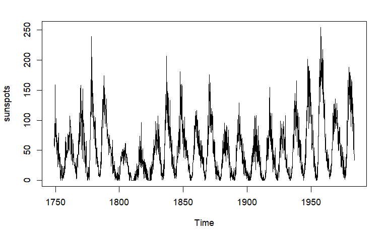

```r
plot(sunspots)
```

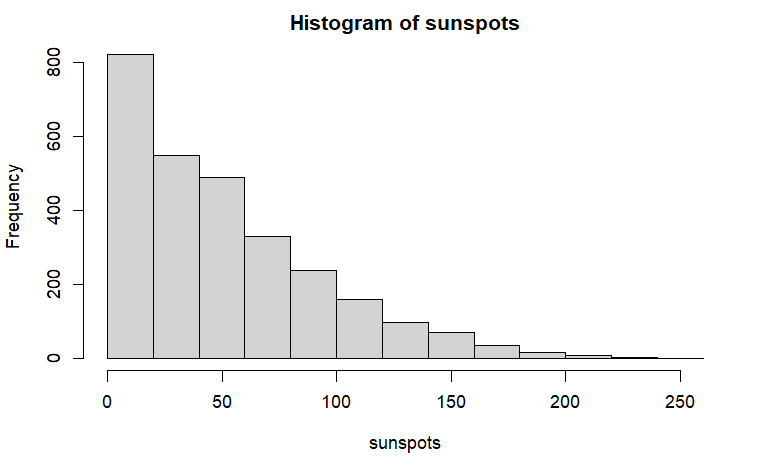

```r
hist(sunspots)
```

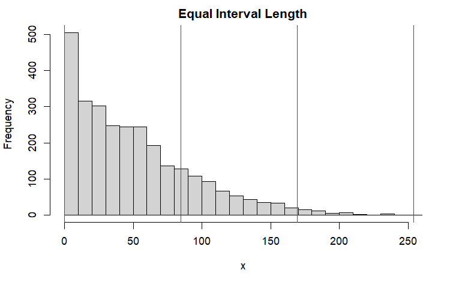

```r
#solution
x <- sunspots
hist(x,breaks=20,main="Equal Interval Length")
abline(v=discretize(x,method='interval',categories=3,onlycuts=TRUE),col='red')
```

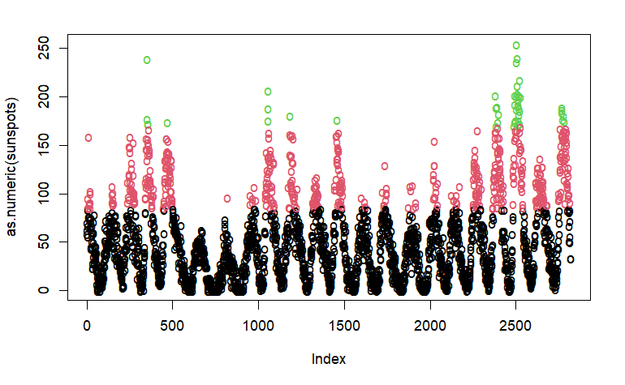

```r
sunspots.discrete <- discretize(x,method='interval',categories=3)
plot(as.numeric(sunspots),pch='o',col=as.numeric(sunspots.discrete))
```

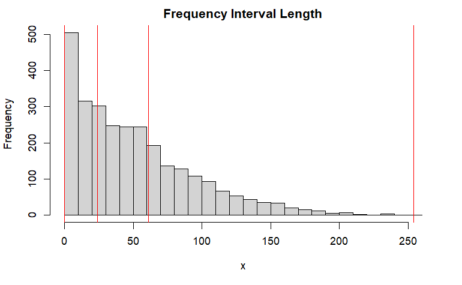

```r
x <- sunspots
hist(x,breaks=20,main="Frequency Interval Length")
abline(v=discretize(x,method='frequency',categories=3,onlycuts=TRUE),col='red')
```

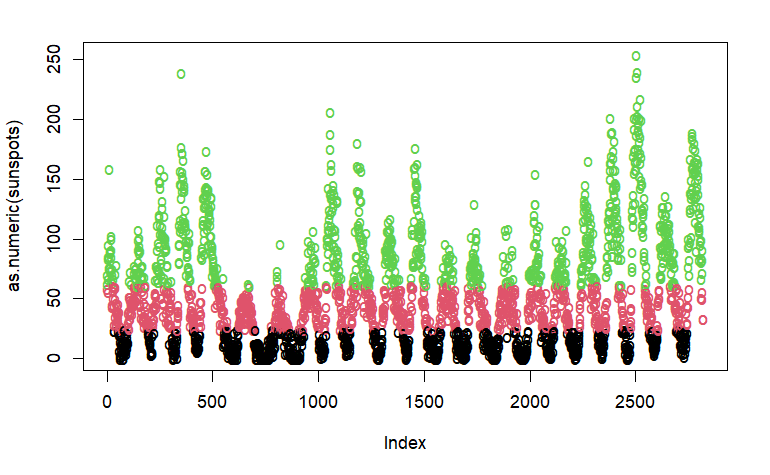

```r
sunspots.discrete <- discretize(x,method='frequency',categories=3)
plot(as.numeric(sunspots),pch='o',col=as.numeric(sunspots.discrete))
```

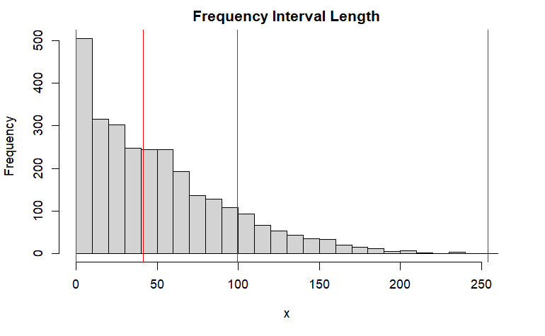

```r
x <- sunspots
hist(x,breaks=20,main="Frequency Interval Length")
abline(v=discretize(x,method='cluster',categories=3,onlycuts=TRUE),col='red')
```

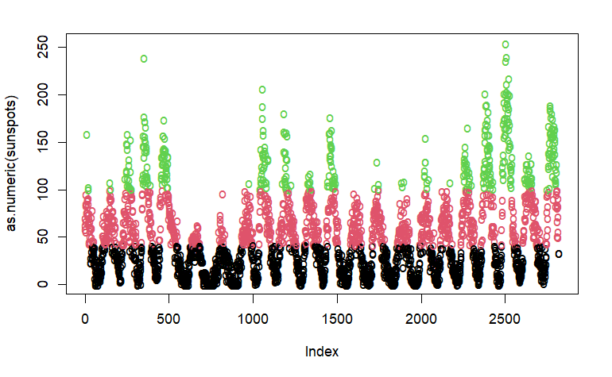

```r
sunspots.discrete <- discretize(x,method='cluster',categories=3)
plot(as.numeric(sunspots),pch='o',col=as.numeric(sunspots.discrete))
```

## Discretización Supervisada

Del paquete `OneR` utiliza la función `optbin` para discretizar la variables del conjunto `iris`.

`optbin(formula, data, method = c("logreg", "infogain", "naive"), na.omit = TRUE, ...)`

```r
data(iris)
library(OneR)
#solucion
iris.discrete<-optbin(formula=Species~.,iris, method = c("logreg"), na.omit = TRUE)

table(iris.discrete$Sepal.Length,iris.discrete$Species)
```

```
              setosa versicolor virginica
  (4.3,5.41]      45          6         1
  (5.41,6.25]      5         30        12
  (6.25,7.9]       0         14        37
```

## Valores perdidos de variables categóricas, nominales y ordinales.

Utiliza la función `mice` y `complete` para recuperar los valores perdidos del `data.frame` *titanic.raw*. Elige el método de recuperación adecuado para el tipo de variable. Comprueba el acierto en la recuperación mediante el coeficiente kappa del paquete `DescTools`.

```r
#library(missForest)
#titanic.raw.miss<-prodNA(titanic.raw,noNA = 0.1)
#save(titanic.raw.miss,file="titanic.raw.miss.RData")
library(mice)
library(VIM)
load('titanic.raw.rdata')
load(file="titanic.raw.miss.RData")
summary(titanic.raw.miss)
```

```
  Class         Sex          Age       Survived
 1st :298   Female: 419   Adult:1876   No  :1356
 2nd :258   Male  :1548   Child:  98   Yes : 635
 3rd :644   NA's  : 234   NA's : 227   NA's: 210
 Crew:792
 NA's:209
```

```
     Class Survived Age Sex
1455     1        1   1   1   0
156      1        1   1   0   1
164      1        1   0   1   1
26       1        1   0   0   2
157      1        0   1   1   1
21       1        0   1   0   2
8        1        0   0   1   2
5        1        0   0   0   3
148      0        1   1   1   1
21       0        1   1   0   2
17       0        1   0   1   2
4        0        1   0   0   3
15       0        0   1   1   2
1        0        0   1   0   3
3        0        0   0   1   3
       209      210 227 234 880
```

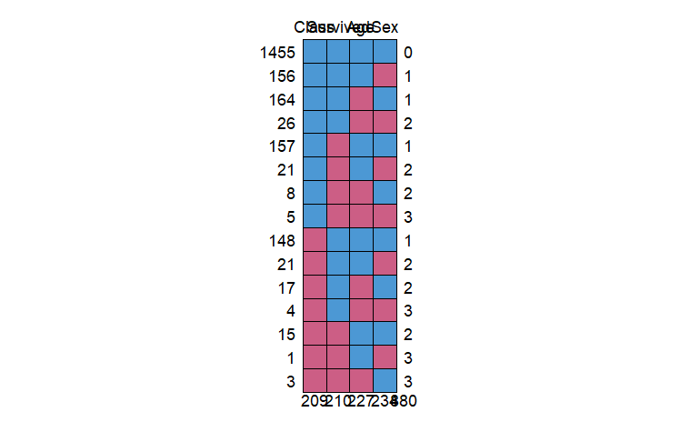

```r
md.pattern(titanic.raw.miss)
```

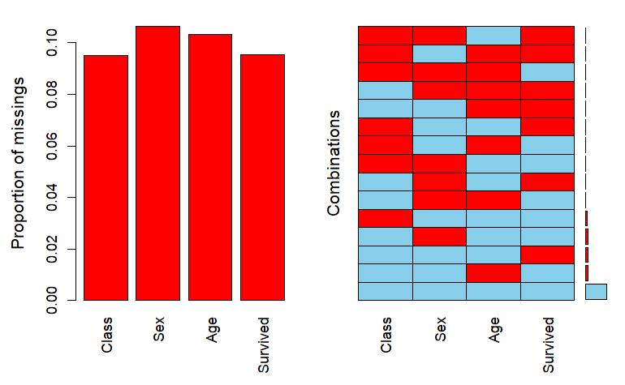

```r
aggr_plot <- aggr(titanic.raw.miss)
```

```r
#solution
aux<-mice(titanic.raw.miss,seed=666,m=1,diagnositics=TRUE)
titanic.raw.restored<-complete(aux)

library(DescTools)
k1 <- titanic.raw$Class[is.na(titanic.raw.miss$Class)]
k2 <- titanic.raw.restored$Class[is.na(titanic.raw.miss$Class)]
CohenKappa(x=k1,y=k2,conf.level = .95)
```

```
      kappa      lwr.ci      upr.ci
0.097402166 0.007917623 0.186886709
```

```r
table(k1,k2)
```

```
      k2
k1     1st 2nd 3rd Crew
  1st    6   5  10    6
  2nd    6   4  11    6
  3rd    8   4  25   25
  Crew  11  10  28   44
```

## Tablas de contingencia

Utilizando la instrucción `xtabs` crea matrices de contingencia para explorar el contenido del conjunto de datos `titanic.raw.rdata`. Comprueba que obtienes los mismos resultados que con la instrucción `table` y además obtienes información de independencia mediante `summary` (`chisq.test()`).

`xtabs(formula = ~., data =)` `prop.table(x, margin = NULL)`

```r
load('titanic.raw.rdata')
#mytable <- table(A,B) # A will be rows, B will be columns

#solution
```

Comprueba la independencia de las variables mediante `chisq.test()` con la supervivencia y ordena las variables según su grado de independencia (p.value) con la variable `Survived` .

```r
#solution
```

Utiliza el paquete `vcd` para crear gráficos de `mosaic` que compruebe las suposiciones de dependencia con la variable `Survived`.

```r
library(vcd)

#solucion
```

Prueba a representar las Tablas de contingencia de más de 2 variables con `ftable`.

```r
#solution
```

## Gráficos de asociación

Estudia el siguiente ejemplo e interpreta el gráfico de asociación.

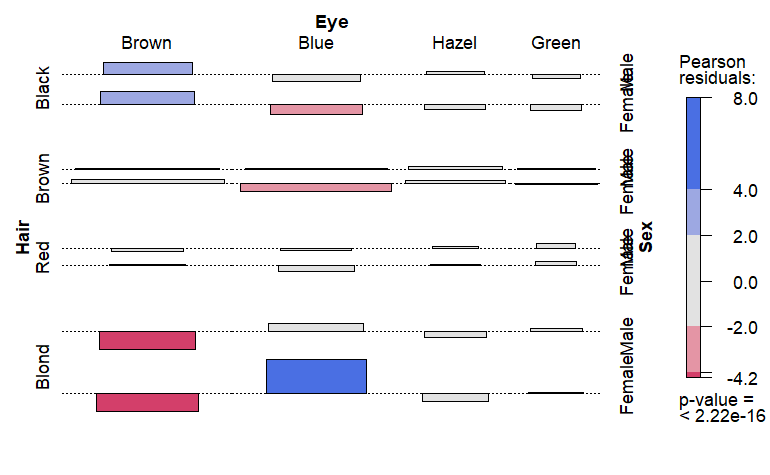

```r
# Association Plot Example
library(vcd)
assoc(HairEyeColor, shade=TRUE)
```